# Income and its Implications on Health

Collaborators: Rohan Bhatnagar, Nikhil Chandrasekar, Pragadeshwar Kalatheswaran, Dhruva Rayasam

# Group Contribution Checkpoints

- Nikhil Chandrashekar Contribution: 95% (Did not contribute to E)
- Dhruva Rayasam Contribution 95% (Did not contribute to A)
- Rohan Bhatnagar Contribution: 90% (Did not contribute to B)
- Pragadeshwar Kalatheeswaran Contribution 95% (Did not contribute to A)

We, all team members, agree together that the above information is true, and we are confident about our contributions to this submitted project/final tutorial. Rohan Bhatnagar, Nikhil Chandrasekar, Pragadeshwar Kalatheswaran, Dhruva Rayasam (05/07/2024)

# Contributions

> Nikhil Chandrasekar: I helped create the project idea and created the Github Page. I also wrote the text for the introduction and data curation step. We lost points on the data curation during our previous checkpoints, so I revamped it so that it’s higher quality and more closely aligns with the goal we have for this tutorial. I was also responsible for writing the conclusion, and contributed to a less hands-on extent with the ML models creation, training, and analysis.

> Dhruva Rayasam: I did the primary analysis for exploring the relationship between teen pregnancy and income. I also contributed to translating our project content to the website we created. As part of my contributions, I utilized two linear regression models (degree=1 and degree=3) to explore the relationship between teen pregnancy and income. I also wrote the code to visualize and interpret the results, as well as evaluating performance metrics to determine the best model.

> Rohan Bhatnagar: I performed one of the original tests in the exploratory analysis, and did the primary analysis to figure out what ML model would allow us to answer our questions. This role entailed implementing the Regression models in our primary analysis, answering one of our proposed questions, and visualizing+interpreting its results. I also wrote text for many sections in this report.

> Pragadeshwar Kalatheswaran: I found the initial dataset and I also performed one of the tests in the exploratory analysis, specifically to discover the difference in median household income between metropolitan and nonmetropolitan areas. Additionally, I did the primary analysis to use two linear regression models of varying polynomial degrees to discover, visualize, and interpret the relationship between median household income and the proportion of people with diabetes. I also contributed to editing the other sections to ensure that there were no loose ends.

## Data Curation

> Before we begin analyzing the data, we needed to import a few python libraries to enable us to do the computations required to gain any meaningful insights. There libraries will also be useful for us when we use statistical analysis techniques and machine learning later in the tutorial

```python
import numpy as np
import pandas as pd
import matplotlib.pyplot as plt
from scipy.stats import wilcoxon
import scipy.stats as stats
from scipy.stats import ttest_ind
from scipy.stats import chi2_contingency
from sklearn.model_selection import train_test_split
from sklearn.linear_model import LinearRegression
from sklearn.preprocessing import PolynomialFeatures
from sklearn.metrics import mean_squared_error, r2_score
```

```python
df_AI_AN_age = pd.read_csv('/content/AI_AN age.csv')
df_AI_AN_facilities = pd.read_csv('/content/AI_AN Facilities.csv')
df_AI_AN_income = pd.read_csv('/content/AI_AN Income.csv')
df_AI_AN_suicide_ages_15_34 = pd.read_csv('/content/AI_AN Suicide - Ages 15-34.csv')
df_behavioral_health_professionals = pd.read_csv('/content/Behavioral Health Professionals.csv')
df_child_abuse = pd.read_csv('/content/Child Abuse.csv')
df_diabetes_prev = pd.read_csv('/content/DiabetesPrev.csv')
df_drug_poisoning_deaths = pd.read_csv('/content/Drug Poisoning Deaths.csv')
df_education = pd.read_csv('/content/Education.csv')
df_farm_injuries_by_age_group = pd.read_csv('/content/Farm Injuries by Age Group.csv')
df_farm_injuries_by_type = pd.read_csv('/content/Farm Injuries by Type.csv')
df_farm_youth = pd.read_csv('/content/Farm Youth.csv')
df_food_desert = pd.read_csv('/content/Food Desert.csv')
df_food_insecure_households = pd.read_csv('/content/Food Insecure Households.csv')
df_gender = pd.read_csv('/content/Gender.csv')
df_government_assistance_program = pd.read_csv('/content/Government Assistance Program.csv')
df_health_insurance_18_and_under = pd.read_csv('/content/Health insurance (18 and under).csv')
df_health_insurance_18_to_64 = pd.read_csv('/content/Health insurance (18 to 64).csv')
df_health_professional_shortage_areas = pd.read_csv('/content/Health Professional Shortage Areas.csv')
df_health_workforce_nurses = pd.read_csv('/content/Health Workforce - nurses.csv')
df_health_workforce_demographics = pd.read_csv('/content/Health Workforce Demographics.csv')
df_health_workforce = pd.read_csv('/content/Health Workforce.csv')
df_heroin_overdoses = pd.read_csv('/content/HeroinOverdoses.csv')
df_hispanic_origin_percent_change = pd.read_csv('/content/Hispanic origin - percent change.csv')
df_hispanic_origin = pd.read_csv('/content/Hispanic origin.csv')
df_hiv_prevalence = pd.read_csv('/content/HIV Prevalence.csv')
df_hs_graduates = pd.read_csv('/content/HS Graduates.csv')
df_income = pd.read_csv('/content/Income.csv')
df_infant_mortality = pd.read_csv('/content/Infant Mortality.csv')
df_life_expectancy = pd.read_csv('/content/Life Expectancy.csv')
df_median_age = pd.read_csv('/content/Median Age.csv')
df_median_household_income = pd.read_csv('/content/Median Household Income.csv')
df_obesity_prev = pd.read_csv('/content/ObesityPrev.csv')
df_omb_metro_status = pd.read_csv('/content/OMB Metro Status.csv')
df_opioid_overdoses = pd.read_csv('/content/OpioidOverdoses.csv')
df_physical_inactivity = pd.read_csv('/content/PhysicalInactivity.csv')
df_population = pd.read_csv('/content/Population.csv')
df_poverty = pd.read_csv('/content/Poverty.csv')
df_race_ethnicity_percent_change = pd.read_csv('/content/Race_ethnicity - percent change.csv')
df_race_ethnicity = pd.read_csv('/content/Race_ethnicity.csv')
df_substance_abuse_treatment = pd.read_csv('/content/Substance Abuse Treatment.csv')
df_teen_births = pd.read_csv('/content/Teen Births.csv')
df_unemployment = pd.read_csv('/content/Unemployment.csv')
df_veteran_gender = pd.read_csv('/content/Veteran Gender.csv')
df_veteran_population = pd.read_csv('/content/Veteran Population.csv')
df_veteran_pos = pd.read_csv('/content/Veteran POS.csv')
df_veteran_race_ethnicity = pd.read_csv('/content/Veteran Race_ethnicity.csv')
df_veteran_service_disability = pd.read_csv('/content/Veteran Service Disability.csv')
df_violent_crime = pd.read_csv('/content/Violent Crime.csv')
```

> Here, we import our CSV files from our dataset. Based on the problem we’re trying to solve, a lot of these data frames aren’t particularly useful to us in the context of the problem we’re trying to solve, so we’ll delete them so we don’t take up unnecessary memory. The code for this is below.

```python
del df_child_abuse
del df_education
del df_gender
del df_hispanic_origin
del df_hispanic_origin_percent_change
del df_hs_graduates
del df_omb_metro_status
del df_race_ethnicity
del df_race_ethnicity_percent_change
del df_veteran_gender
del df_veteran_population
del df_veteran_pos
del df_veteran_race_ethnicity
del df_veteran_service_disability
del df_violent_crime
```

> The last step in the process would be to drop any rows with null values. Null values can interfere with data processing by skewing results or just outright not allowing code to compile, so eliminating them would be the best course of action. We can do this using the dropna() command in Pandas. However, the data we got from Kaggle was already sufficiently processed, so this has already been done for us and therefore we don’t need to do it.

> You may notice that we will have several smaller data frames and as opposed to fewer but larger ones. We chose to do this because we will be doing our analysis on specific multiple statistics we are trying to look at, and combining these data frames would result in a larger data frame which will have multiple columns that may not be used in a specific procedure. However, they would slow the procedure down, making each computation more expensive, which therefore makes having multiple smaller data frames like we have right now much more appealing.

> If you were to print some of the data, you’d see that it is sorted by counties, and each county’s state is also given. This knowledge is important to understand our findings going forward.

## Exploratory Data Analysis

> The next step in the Data Lifecycle is to explore the data and gain a better understanding about it. Our central question revolves around income and its relationship to health, so the majority of our exploratory analysis will be to understand both sides of that question independently, while our primary analysis will be more centered around connecting the two.

### 1. Is the Median Household Income above the "living wage?"

> The first thing we will be exploring is the median income for all the counties in our data.

> MIT published recently that the livable household income for the average American family (2 adults and 2 children) in 2016 is 15.84 dollars and hour. If both adults are working, this translates to roughly 65,894.4 dollars a year before taxes. We want to see if on average, Americans made more than the “living wage” back in 2016.

> To do this, we will be using a hypothesis test, with the null and alternative hypothesis written below. And we will use an alpha level of 0.05

> $H_{0}$: $μ_{0}$ = 65894.4  
> $H_{A}$: $μ_{0}$ ≠ 65894.4

> Usually, we would use a t-test, but one of the requirements for this is that the data follow the normal distribution. We can check that by using the .hist() command on the specific column in our dataframe

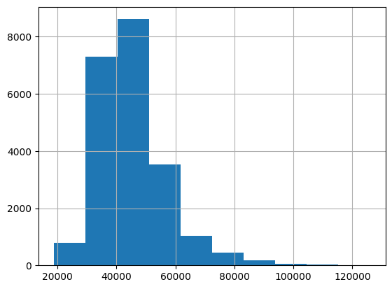

```python
df_median_household_income['medianinc'].hist()
# The data doesn't look like it follows the normal distribution,
# so we can't use a t-test. Instead, we will use a non-parametric test
```

```python
# Perform Mann-Whitney U test
w, p = wilcoxon(df_median_household_income['medianinc'] - 65894.4)
print("test statistics: ", w)
print("P value: ", p)
```

```
test statistics:  5436935.0
P value:  0.0
```

> We get an output of 0 from this test, which means the p value was so low that it got rounded down to 0. Therefore, we can reject the null hypothesis and adopt the alternative hypothesis that the average median household income for all the counties differs from $ 65,894.4.

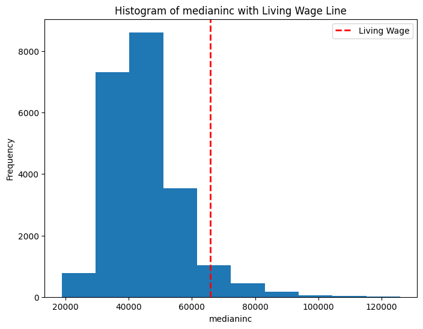

```python
# Graphing histogram with the poverty line income drawn on it
plt.figure(figsize=(8, 6))
plt.hist(df_median_household_income['medianinc'])

# Calculate and plot median
plt.axvline(65894.4, color='red', linestyle='dashed', linewidth=2, label=f'Living Wage')

# Add legend
plt.legend()

plt.title('Histogram of medianinc with Living Wage Line')
plt.xlabel('medianinc')
plt.ylabel('Frequency')
plt.show()
```

We can see the majority of the data falls to the left of the Living Wage line, which makes sense given our p value of almost 0. We can find out what percentage of the counties are on the left of that line by comparing their median income with $65,894.4, which is exactly what the function below does.

```python
# Counts, in different cell than previous
count = 0
for value in df_median_household_income['medianinc']:
    # Check if the value is less than 65894.4
    if value < 65894.4:
        count += 1

print("Percent of counties with medium income under Living Wage: ", count/df_median_household_income['medianinc'].count() * 100)
```

```
Percent of counties with medium income under Living Wage:  94.3615860312841
```

We can see that a whopping 94% of counties have a median income that falls below the Living Wage line, and that knowledge will be important for us moving forward.

### 2. Is there a statistically significant difference in median household income between Metropolitan and Nonmetropolitan Areas?

> We know that there are a lot of counties with a median household income that is below the Living Wage amount, but does whether or not that county is metropolitan or not affect that? We will explore that by looking at the average median incomes (sounds like a weird statement I know) of Metropolitan and Non-metropolitan areas. Once again, we will be using a hypothesis test to assess this.

> To compare these two means, we decided to use a two sample t test, with an alpha level of 0.05. The null and alternative hypotheses are written below.

> $H_{0}$: There is no statistically significant difference in median household income between metropolitan and nonmetropolitan areas.  
> $H_{A}$: There is a statistically significant difference in median household income between metropolitan and nonmetropolitan areas.

> To do this, we assume that the samples are both normally distributed and independent. We can assume independence due to the random sampling required to procure our data, and we can assume the data is normally distributed thanks to the large sample size and the Central Limit Theorem.

> We won’t be running this test on the median household income data directly. Instead, we will partition the data into two separate dataframes, one containing the median incomes for metropolitan counties and the other for non-metropolitan counties. We have the code that splits the data and runs the test below.

```python
metro_incomes = df_median_household_income[df_median_household_income['metro_nonmetro'] == 'Metropolitan']['medianinc']
nonmetro_incomes = df_median_household_income[df_median_household_income['metro_nonmetro'] == 'Nonmetropolitan']['medianinc']

t_value, p_value = ttest_ind(metro_incomes, nonmetro_incomes, equal_var = False)
print("T statistic: ", t_value)
print("P value: ", p_value)
```

```
T statistic:  61.374095620194986
P value:  0.0
```

> Because our p-value of approximately 0.0, which is less than our alpha value of 0.05, we have sufficient evidence to reject the null hypothesis. The hypothesis test suggests that there is a statistically significant difference in median household income between metropolitan and nonmetropolitan areas.

> To highlight the difference in the means of the median household incomes, we can use visual aids. Specifically, we will be using a bar graph to show the difference between the means in more general terms, and box plots to show the difference in the two distributions.

> We will be using Matplotlib again to illustrate this.

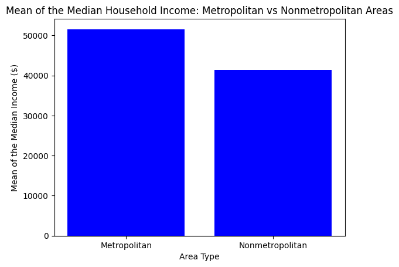

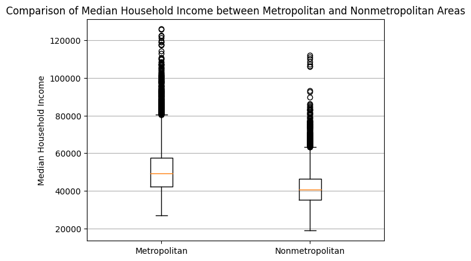

```python
mean_metro = metro_incomes.mean()
mean_nonmetro = nonmetro_incomes.mean()

plt.bar([0,1], [mean_metro, mean_nonmetro], color = 'blue')
plt.title('Mean of the Median Household Income: Metropolitan vs Nonmetropolitan Areas')
plt.xlabel('Area Type')
plt.xticks([0,1], ['Metropolitan', 'Nonmetropolitan'])
plt.ylabel('Mean of the Median Income ($)')

plt.show()

plt.boxplot([metro_incomes, nonmetro_incomes], labels = ['Metropolitan', 'Nonmetropolitan'])
plt.title('Comparison of Median Household Income between Metropolitan and Nonmetropolitan Areas')
plt.ylabel('Median Household Income')
plt.grid(axis = 'y')
plt.show()
```

> It is clear from these two plots that there is indeed a visible difference in the average median household income between metropolitan and nonmetropolitan areas, which allows us to visually support our conclusion from the two-sample T-test. It’s also good to note that there are a lot of outliers in our data, specifically counties with median incomes much higher than the others. This information will be useful in our further analysis.

### 3. Comparison of Life Expectancy between Metropolitan and Nonmetropolitan Areas

> Now that we’ve done our analysis with the classification of a county and its income, we should do the same with some health metric. To spice things up, we can use a Chi-Squared test to do this, and we will be comparing the life expectancy of metropolitan and non-metropolitan areas.

> Like before, our alpha is 0.05 and our null and alternative hypothesis are below.

> $H_{0}$: There is no statistically significant difference in life expectancy between metropolitan and nonmetropolitan areas.  
> $H_{A}$: There is a statistically significant difference in life expectancy between metropolitan and nonmetropolitan areas.

> In order to do this, we must classify the life expectancy data as either high or low. We can do this with the code above, where we define the threshold between high and low life expectancy as 71, which is 10 years above the retirement age in 2016. We can do that with this code

```python
threshold = 71
df_life_expectancy['life_expectancy_categorized'] = ['high' if x >= threshold else 'low' for x in df_life_expectancy['life_expectancy']]
```

> We can now run the test on this modified version of the data and graph it using Matplotlib like we did before

```
Chi-squared statistic: 4.251934709862956
P-value: 0.03920564192197968
```

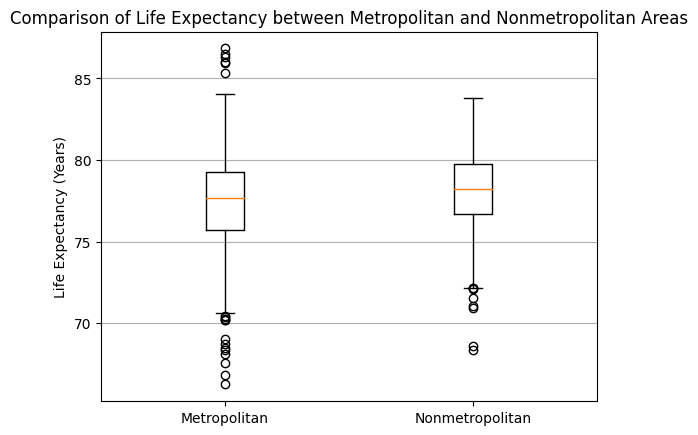

```python
# Chi squared test
contingency_table = pd.crosstab(df_life_expectancy['metro_nonmetro'], df_life_expectancy['life_expectancy_categorized'])
chi2, p_value, _, _ = chi2_contingency(contingency_table)

print("Chi-squared statistic:", chi2)
print("P-value:", p_value)

# Graphing
high = df_life_expectancy[df_life_expectancy['metro_nonmetro'] == 'Nonmetropolitan']['life_expectancy']
low = df_life_expectancy[df_life_expectancy['metro_nonmetro'] == 'Metropolitan']['life_expectancy']

plt.boxplot([high, low], labels = ['Metropolitan', 'Nonmetropolitan'])
plt.title('Comparison of Life Expectancy between Metropolitan and Nonmetropolitan Areas')
plt.ylabel('Life Expectancy (Years)')
plt.grid(axis = 'y')
plt.show()
```

> Overall in this exploratory analysis, we discovered that a majority of these countries have lower median incomes than what is required to live by as per the Living Wage, and that there is a significant difference in median household income and life expectancy across metropolitan and nonmetropolitan areas. We now have a better understanding of the income and health across these counties, which will be helpful in our more involved analysis later on.

# Primary Analysis Methodology

> To answer the following questions, we will use linear regression with a polynomial and linear fit model on the respective data. We do this to find a best-fitting line that can give us an educated prediction for the dependent variable given the independent; to make the best predictions, it is a question of finding a line that minimizes the distance between predicted values and the actual data. To achieve this goal, we can perform many types of linear regression operations that create best fit lines that may be linear, polynomial, sinusoidal and more; for our purposes, we will be comparing how a linear and cubic model predicts the data.

> Additionally, to measure the effectiveness of this model we will use MSE (mean squared error) and R2 as performance metrics to measure how well our model fits the data. MSE measures how far the predicted data is from the actual data, while R2 measures the strength of the relationship between the two variables. R2 also indicates to us the amount of variance in the dependent variable that can be explained by the independent variable. For us, R2 indicates the amount of variance in teen pregnancies income can explain.

> To implement the models and performance metrics, we will use the [sklearn package](https://scikit-learn.org/stable/supervised_learning.html#supervised-learning), specifically [LinearRegression](https://scikit-learn.org/stable/modules/generated/sklearn.linear_model.LinearRegression.html), [PolynomialFeatures](https://scikit-learn.org/stable/modules/generated/sklearn.preprocessing.PolynomialFeatures.html), [sklearn train-test-split](https://scikit-learn.org/stable/modules/generated/sklearn.model_selection.train_test_split.html), [mean_squared_error](https://scikit-learn.org/stable/modules/generated/sklearn.metrics.mean_squared_error.html), and [r2_score](https://scikit-learn.org/stable/modules/generated/sklearn.metrics.r2_score.html).

# Primary Analysis: Question 1 (Relationship between income and life expectancy)

> During this phase of the Data lifecycle, we attempt to obtain a predictive model for our data. So we will implement several types of regression models, and pick the one that has the best fit, measured by the r-squared and mean squared error (MSE) metrics. First let's import the necessary libraries. Train-test-split allows us to split our data randomly into training and testing sets. We have also imported some metrics to help us better understand our regression models.

> Let's prepare our data and set up our regression models. We will be using both Linear Regression and a Polynomial Fit, as it may better capture complex trends in the data.

```python
# Prepare data
df_average_medianinc = df_median_household_income.groupby('county_name')['medianinc'].mean().reset_index()
df_income_life_expectancy = pd.merge(df_average_medianinc, df_life_expectancy, on='county_name')

random_state = 42
np.random.seed(random_state)

medianinc_array = df_income_life_expectancy['medianinc'].to_numpy()
life_expectancy_array = df_income_life_expectancy['life_expectancy'].to_numpy()

# initialize training and test sets
income_train, income_test, life_expectancy_train, life_expectancy_test = train_test_split(
    medianinc_array, life_expectancy_array, test_size=0.25, random_state=random_state)

df_income_life_expectancy.head()
```

|  | county_name | medianinc | index | year | fips | state_fips | county_fips | state_name | state_abbr | metro_nonmetro | life_expectancy | population | life_expectancy_categorized |
| --- | --- | --- | --- | --- | --- | --- | --- | --- | --- | --- | --- | --- | --- |
| 0 | Abbeville County | 35505.714286 | 2316 | 2010 | 45001 | 45 | 1 | South Carolina | SC | Nonmetropolitan | 76.90 | 25339 | high |
| 1 | Abbeville County | 35505.714286 | 5458 | 2014 | 45001 | 45 | 1 | South Carolina | SC | Nonmetropolitan | 76.96 | 24892 | high |
| 2 | Acadia Parish | 37910.000000 | 1113 | 2010 | 22001 | 22 | 1 | Louisiana | LA | Metropolitan | 74.21 | 61850 | high |
| 3 | Acadia Parish | 37910.000000 | 4255 | 2014 | 22001 | 22 | 1 | Louisiana | LA | Metropolitan | 74.23 | 62562 | high |
| 4 | Accomack County | 37662.714286 | 2820 | 2010 | 51001 | 51 | 1 | Virginia | VA | Nonmetropolitan | 75.83 | 33164 | high |

## Linear fit.

```python
# Training the linear regression model
model = LinearRegression()
model.fit(income_train.reshape(-1, 1), life_expectancy_train)
LE_linear_train_pred = model.predict(income_train.reshape(-1, 1))
LE_linear_test_pred = model.predict(income_test.reshape(-1, 1))
```

## Polynomial fit.

```python
# transforming the data
transformer = PolynomialFeatures(degree=3)
income_train_linear = transformer.fit_transform(income_train.reshape(-1, 1))
income_test_linear = transformer.fit_transform(income_test.reshape(-1, 1))

# Training the linear regression model
convex_model = LinearRegression()
convex_model.fit(income_train_linear, life_expectancy_train)
LE_train_pred_poly = convex_model.predict(income_train_linear)
LE_test_pred_poly = convex_model.predict(income_test_linear)
```

Let's compare the models.

```python
# Comparison of the lines
mse_train_linear = mean_squared_error(life_expectancy_train, LE_linear_train_pred)
r2_train_linear = r2_score(life_expectancy_train, LE_linear_train_pred)
mse_test_linear = mean_squared_error(life_expectancy_test, LE_linear_test_pred)
r2_test_linear = r2_score(life_expectancy_test, LE_linear_test_pred)

print(f"Linear Regression - Train MSE: {mse_train_linear:.2f}, Train R^2: {r2_train_linear:.2f}")
print(f"Linear Regression - Test MSE: {mse_test_linear:.2f}, Test R^2: {r2_test_linear:.2f}")

mse_train_poly = mean_squared_error(life_expectancy_train, LE_train_pred_poly)
r2_train_poly = r2_score(life_expectancy_train, LE_train_pred_poly)
mse_test_poly = mean_squared_error(life_expectancy_test, LE_test_pred_poly)
r2_test_poly = r2_score(life_expectancy_test, LE_test_pred_poly)

print(f"Polynomial Regression - Train MSE: {mse_train_poly:.2f}, Train R^2: {r2_train_poly:.2f}")
print(f"Polynomial Regression - Test MSE: {mse_test_poly:.2f}, Test R^2: {r2_test_poly:.2f}")
```

```
Linear Regression - Train MSE: 3.96, Train R^2: 0.26
Linear Regression - Test MSE: 4.10, Test R^2: 0.26
Polynomial Regression - Train MSE: 3.76, Train R^2: 0.30
Polynomial Regression - Test MSE: 3.90, Test R^2: 0.30
```

## Visualizing our models (Question 1)

> Let's visualize our regression models with pyplot. We can visually observe the fit of our models, and compare our visual results with the analytical metrics ($r^2$, mean squared error).

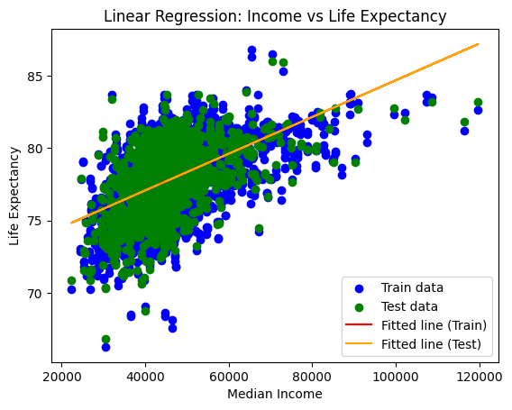

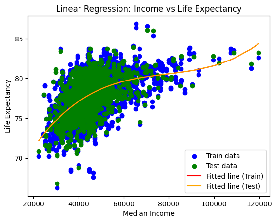

```python
# Plotting the results (linear)
plt.scatter(income_train, life_expectancy_train, color='blue', label='Train data')
plt.scatter(income_test, life_expectancy_test, color='green', label='Test data')
plt.plot(income_train, LE_linear_train_pred, color='red', label='Fitted line (Train)')
plt.plot(income_test, LE_linear_test_pred, color='orange', label='Fitted line (Test)')
plt.title('Linear Regression: Income vs Life Expectancy')
plt.xlabel('Median Income')
plt.ylabel('Life Expectancy')
plt.legend()
plt.show()

# Plotting the results (polynomial)
plt.scatter(income_train, life_expectancy_train, color='blue', label='Train data')
plt.scatter(income_test, life_expectancy_test, color='green', label='Test data')
plt.plot(sorted(income_train), LE_train_pred_poly[np.argsort(income_train)], color='red', label='Fitted line (Train)')
plt.plot(sorted(income_test), LE_test_pred_poly[np.argsort(income_test)], color='orange', label='Fitted line (Test)')
plt.title('Linear Regression: Income vs Life Expectancy')
plt.xlabel('Median Income')
plt.ylabel('Life Expectancy')
plt.legend()
plt.show()
```

> The lines look fitted, and we can see the the polynomial fit captures the curved increase at higher median incomes. This is reflected in the r^2 value, as the polynomial fit has a higher value than the linear regression. We can also see that the MSE is quite high for both, which makes sense, as there is a lot of residual error and the data is widely distributed across every income.

> The above plots show the results of a linear regression model using both a line of best fit and polynomial feature with degree = 3 to predict life expectancy based on median income. The scatter plots represent the data points, with blue indicating entries in the training set, and green indicating entries of the test set. There are two lines of best fit, one formed from each dataset. The model captures a moderate positive relationship between the two categories, indicated by a postivie R-squared (R²) value. This indicates that a higher income is typically associated with higher life expectancy.

> The R-squared (R²) value is 0.3 for the polynomial model, indicating that the model captures about 30% of the variance present in the data.

# Primary Analysis: Question 2 (Relationship Between Income and Teen Pregnancy)

> To measure the relationship between teen pregnancy and income, we must first get the percentage of teen births compared to the female population of that county. We then group median household income and the teen pregnancy rate by county and aggregate by the mean. By performing an inner merge with these two datasets on county_name, we can correspond teen pregnancy rate with the median income for each county.

```python
# prepare the data

df_teen_births['births_perc'] = df_teen_births['births_15_to_19'] / df_teen_births['female_population_15_to_19']

df_average_medianinc = df_median_household_income.groupby('county_name')['medianinc'].mean().reset_index()
df_avg_pregnancies = df_teen_births.groupby('county_name')['births_perc'].mean().reset_index()

df_inc_preg = pd.merge(df_average_medianinc, df_avg_pregnancies, on=['county_name'], how='inner')

medianinc_array = df_inc_preg['medianinc'].to_numpy()
preg_array = df_inc_preg['births_perc'].to_numpy()

random_state = 42
np.random.seed(random_state)

income_train, income_test, preg_train, preg_test = train_test_split(medianinc_array, preg_array, test_size=0.25, random_state=random_state)
```

# Linear Fit

Here, we fit the data to a linear model and execute our predictions.

```python
linear_transformer = PolynomialFeatures(degree=1)
xlintrain = linear_transformer.fit_transform(income_train.reshape(-1, 1))
xlintest = linear_transformer.fit_transform(income_test.reshape(-1, 1))

linear_model = LinearRegression()
linear_model.fit(xlintrain, preg_train)
Y_linear_train_pred = linear_model.predict(xlintrain)
Y_linear_test_pred = linear_model.predict(xlintest)
```

# Polynomial Fit

Here, we fit the data to a convex model and execute our predictions.

```python
convex_transformer = PolynomialFeatures(degree=3)
xcontrain = convex_transformer.fit_transform(income_train.reshape(-1, 1))
xcontest = convex_transformer.fit_transform(income_test.reshape(-1, 1))

convex_model = LinearRegression()
convex_model.fit(xcontrain, preg_train)
Y_convex_train_pred = convex_model.predict(xcontrain)
Y_convex_test_pred = convex_model.predict(xcontest)
```

# Compare Both Methods of Linear Regression

Compared to the degree=1 linear regression, our convex model seems to be a better fit for the data. It has a better R2 score for both train and test sets, as well as a lower MSE for both train and test.

```python
# compare both
mse_train_linear = mean_squared_error(preg_train, Y_linear_train_pred)
r2_train_linear = r2_score(preg_train, Y_linear_train_pred)
mse_test_linear = mean_squared_error(preg_test, Y_linear_test_pred)
r2_test_linear = r2_score(preg_test, Y_linear_test_pred)

print(f"Linear Regression - Train MSE: {mse_train_linear}, Train R^2: {r2_train_linear:.2f}")
print(f"Linear Regression - Test MSE: {mse_test_linear}, Test R^2: {r2_test_linear:.2f}")

mse_train_poly = mean_squared_error(preg_train, Y_convex_train_pred)
r2_train_poly = r2_score(preg_train, Y_convex_train_pred)
mse_test_poly = mean_squared_error(preg_test, Y_convex_test_pred)
r2_test_poly = r2_score(preg_test, Y_convex_test_pred)

print(f"Polynomial Regression - Train MSE: {mse_train_poly}, Train R^2: {r2_train_poly:.2f}")
print(f"Polynomial Regression - Test MSE: {mse_test_poly}, Test R^2: {r2_test_poly:.2f}")
```

```
Linear Regression - Train MSE: 0.00021592191770383794, Train R^2: 0.30
Linear Regression - Test MSE: 0.00020724642490777415, Test R^2: 0.38
Polynomial Regression - Train MSE: 0.00019818717627098842, Train R^2: 0.36
Polynomial Regression - Test MSE: 0.00018169980454433958, Test R^2: 0.45
```

# Primary Analysis: Question 2 (Relationship between Income and Teen Pregnancy) Visualization

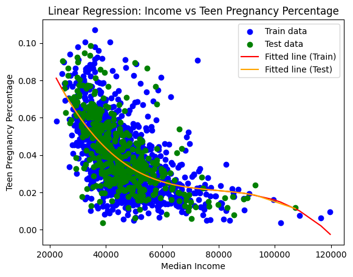

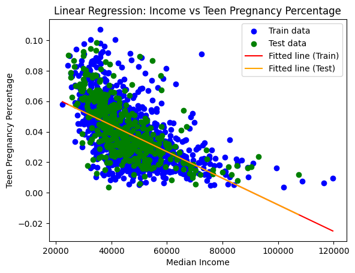

```python
# Plotting the results
plt.scatter(income_train, preg_train, color='blue', label='Train data')
plt.scatter(income_test, preg_test, color='green', label='Test data')
plt.plot(sorted(income_train), Y_convex_train_pred[np.argsort(income_train)], color='red', label='Fitted line (Train)')
plt.plot(sorted(income_test), Y_convex_test_pred[np.argsort(income_test)], color='orange', label='Fitted line (Test)')
plt.title('Linear Regression: Income vs Teen Pregnancy Percentage')
plt.xlabel('Median Income')
plt.ylabel('Teen Pregnancy Percentage')
plt.legend()
plt.show()

# Plotting the results (linear)
plt.scatter(income_train, preg_train, color='blue', label='Train data')
plt.scatter(income_test, preg_test, color='green', label='Test data')
plt.plot(sorted(income_train), Y_linear_train_pred[np.argsort(income_train)], color='red', label='Fitted line (Train)')
plt.plot(sorted(income_test), Y_linear_test_pred[np.argsort(income_test)], color='orange', label='Fitted line (Test)')
plt.title('Linear Regression: Income vs Teen Pregnancy Percentage')
plt.xlabel('Median Income')
plt.ylabel('Teen Pregnancy Percentage')
plt.legend()
plt.show()
```

> The plot above visually demonstrates the relationship between income and teen pregnancy rates, averaged across counties. The blue data points represent training data while the green represents test data. The red line demonstrates the fitted line for training data and the orange line demonstrates a fitted line for test data.

# Primary Analysis: Question 3 (Relationship between income and diabetes)

To determine the correlation between median household income and diabetes, we will use linear regression (degree=1 and degree=3) to see if we can find a regression model that predicts the data reliably. We will use MSE and R2 as performance metrics to measure the effectiveness of these models. To implement the models and performance metrics, we will use the [sklearn package](https://scikit-learn.org/stable/supervised_learning.html#supervised-learning), specifically [LinearRegression](https://scikit-learn.org/stable/modules/generated/sklearn.linear_model.LinearRegression.html), [PolynomialFeatures](https://scikit-learn.org/stable/modules/generated/sklearn.preprocessing.PolynomialFeatures.html), [sklearn train-test-split](https://scikit-learn.org/stable/modules/generated/sklearn.model_selection.train_test_split.html), [mean_squared_error](https://scikit-learn.org/stable/modules/generated/sklearn.metrics.mean_squared_error.html), and [r2_score](https://scikit-learn.org/stable/modules/generated/sklearn.metrics.r2_score.html).

To measure the relationship between diabetes and median household income, we must first get the proportion of people with diabetes compared to the total population of that county. We then group median household income and the diabetes proportion by county and aggregate by the mean. By performing an inner merge with these two datasets on county_name, we can correspond the diabetes proportion with the median income for each county.

```python
# Preparing the data
df_diabetes_prev['diabetes_proportion'] = df_diabetes_prev['diabetes_population_20_over'] / df_diabetes_prev['total_population_inferred_20_over']

df_average_diabetes_proportion = df_diabetes_prev.groupby('county_name')['diabetes_proportion'].mean().reset_index()
df_average_medianinc = df_median_household_income.groupby('county_name')['medianinc'].mean().reset_index()

df_income_diabetes = pd.merge(df_average_medianinc, df_average_diabetes_proportion, on='county_name')

medianinc_array = df_income_diabetes['medianinc'].to_numpy()
diabetes_proportion_array = df_income_diabetes['diabetes_proportion'].to_numpy()

random_state = 42
np.random.seed(random_state)

income_train, income_test, diabetes_train, diabetes_test = train_test_split(medianinc_array, diabetes_proportion_array, test_size=0.25, random_state=random_state)
df_income_diabetes.head()
```

[output not shown]

## Linear fit

```python
# Training the linear regression model
linear_transformer = PolynomialFeatures(degree=1)
xlintrain = linear_transformer.fit_transform(income_train.reshape(-1, 1))
xlintest = linear_transformer.fit_transform(income_test.reshape(-1, 1))

linear_model = LinearRegression()
linear_model.fit(xlintrain, diabetes_train)
Y_linear_train_pred = linear_model.predict(xlintrain)
Y_linear_test_pred = linear_model.predict(xlintest)
```

# Polynomial (Cubic) fit

```python
# Training the linear regression model
cubic_transformer = PolynomialFeatures(degree=3)
xcubtrain = cubic_transformer.fit_transform(income_train.reshape(-1, 1))
xcubtest = cubic_transformer.fit_transform(income_test.reshape(-1, 1))

cubic_model = LinearRegression()
cubic_model.fit(xcubtrain, diabetes_train)
Y_cubic_train_pred = cubic_model.predict(xcubtrain)
Y_cubic_test_pred = cubic_model.predict(xcubtest)
```

Let's compare the models.

```python
mse_linear_test_poly = mean_squared_error(diabetes_test, Y_linear_test_pred)
r2_linear_test_poly = r2_score(diabetes_test, Y_linear_test_pred)

mse_linear_train_poly = mean_squared_error(diabetes_train, Y_linear_train_pred)
r2_linear_train_poly = r2_score(diabetes_train, Y_linear_train_pred)

print("Linear Dataset with Polynomial Features:")
print(f"Train - MSE: {mse_linear_train_poly:.4f}, R^2: {r2_linear_train_poly:.4f}")
print(f"Test - MSE: {mse_linear_test_poly:.4f}, R^2: {r2_linear_test_poly:.4f}\n")

mse_cubic_test_poly = mean_squared_error(diabetes_test, Y_cubic_test_pred)
r2_cubic_test_poly = r2_score(diabetes_test, Y_cubic_test_pred)

mse_cubic_train_poly = mean_squared_error(diabetes_train, Y_cubic_train_pred)
r2_cubic_train_poly = r2_score(diabetes_train, Y_cubic_train_pred)

print("Cubic Dataset with Polynomial Features:")
print(f"Train - MSE: {mse_cubic_train_poly:.4f}, R^2: {r2_cubic_train_poly:.4f}")
print(f"Test - MSE: {mse_cubic_test_poly:.4f}, R^2: {r2_cubic_test_poly:.4f}\n")
```

```
Linear Dataset with Polynomial Features:
Train - MSE: 0.0003, R^2: 0.3249
Test - MSE: 0.0002, R^2: 0.3375

Cubic Dataset with Polynomial Features:
Train - MSE: 0.0002, R^2: 0.3931
Test - MSE: 0.0002, R^2: 0.3621
```

## Visualizing our models (Question 3)

> Let's visualize our regression models with pyplot. We can visually observe the fit of our models, and compare our visual results with the analytical metrics ($r^2$, mean squared error).

[figure not shown]

[figure not shown]

```python
# Plotting the results (linear)
plt.scatter(income_train, diabetes_train, color='blue', label='Train data')
plt.scatter(income_test, diabetes_test, color='green', label='Test data')
plt.plot(sorted(income_train), Y_linear_train_pred[np.argsort(income_train)], color='red', label='Fitted line (Train)')
plt.plot(sorted(income_test), Y_linear_test_pred[np.argsort(income_test)], color='orange', label='Fitted line (Test)')
plt.title('Linear Regression: Income vs Diabetes Percentage')
plt.xlabel('Median Income')
plt.ylabel('Diabetes Proportion')
plt.legend()
plt.show()

# Plotting the results (cubic)
plt.scatter(income_train, diabetes_train, color='blue', label='Train data')
plt.scatter(income_test, diabetes_test, color='green', label='Test data')
plt.plot(sorted(income_train), Y_cubic_train_pred[np.argsort(income_train)], color='red', label='Fitted line (Train)')
plt.plot(sorted(income_test), Y_cubic_test_pred[np.argsort(income_test)], color='orange', label='Fitted line (Test)')
plt.title('Cubic Regression: Income vs Diabetes Percentage')
plt.xlabel('Median Income')
plt.ylabel('Diabetes Proportion')
plt.legend()
plt.show()
```

> The two plots above showcase the results of polynomial regression models of different degrees, linear and cubic, aimed at predicting the diabetes percentage based on the median household income in U.S. counties. The first plot, which employs linear regression with polynomial features, displays the training data as blue dots and the testing data as green dots, with the fitted lines for each set shown in red and orange, respectively. The model's performance, indicated by a Mean Squared Error (MSE) of 0.0003 for the training set and 0.0002 for the testing set, along with R² values of 0.3249 and 0.3375, suggests that the linear model explains around 32-34% of the variance in the data. The second plot uses a cubic regression model, similarly visualizing the training and testing data points and their corresponding fitted lines. The cubic model shows an improved fit, with MSE values of 0.0002 for both sets and R² values of 0.3931 and 0.3621, indicating that the cubic model captures the relationship better, explaining around 36-39% of the variance. Both models reveal a negative correlation between median income and diabetes percentage, with higher income generally associated with a lower diabetes rate. The cubic regression model, however, fits the data more accurately, highlighting the importance of selecting an appropriate polynomial degree to capture non-linear relationships. Additionally, the close performance metrics between the training and testing sets in both models suggest effective generalization without significant overfitting.

## Conclusion

> In the last part of the life cycle, we are to analyze our findings to extract some meaning from what we’ve done as a whole. We set out to see if there was a relationship between income and health, and using machine learning and data analysis techniques, we were able to reach some conclusions. Health is an arbitrary concept, so we put it in more definitive terms by comparing income to life expectancy, teen pregnancy, and diabetes prevalence. That way, we can assess people’s health conditions with life expectancy and diabetes prevalence, and we can use teen pregnancy as a way of analyzing the health infrastructure in the area. Throughout our analysis, we’ve seen that there is some correlation between income and health, with varying levels of strength across indicators for the health of a county. Our models didn't have incredibly strong predictive power, but the fact that we have some non-neglible results from our training shows that there is a connection between the two. It’s very obvious that money is not spread equally across all people, as seen in our exploratory analysis, and as a result of this data lifecycle tutorial, we now know that unequal funds lead to unequal health statuses. This knowledge is important in inspiring social change, and although there isn't a tutorial like this one on how to do that, there are people around the world doing their best to help those around them and even the playing field for all. We in our everyday lives can help by physically getting involved, or at the least showing our support for these causes.

> This tutorial answered the question we sought to explore. We now know that the wealth disparity in the United States transfers into the health of our people.